```python
import pandas as pd
import numpy as np
import matplotlib.pyplot as plt
%matplotlib inline

from sklearn.datasets import load_digits
from sklearn.preprocessing import StandardScaler
from sklearn.discriminant_analysis import LinearDiscriminantAnalysis as LDA
from sklearn.model_selection import train_test_split
from sklearn.ensemble import RandomForestClassifier
from sklearn.metrics import accuracy_score, confusion_matrix, classification_report

import warnings
warnings.filterwarnings("ignore")
```

# Problem Statement:

You have been provided with a multi dimensional data that contains information on certain images. Using machine learning, you should be able to predict the images on the new set of data using the model that you have trained on the existing data.

Dataset Information:

Each point in the data is an 8x8 image.

Classes 10

Samples per class ~180

Samples total 1797

Dimensionality 64

Features integers 0-16

Note: Load the dataset from sklearn.datasets.load_digits()

# Q1. What will be the output of the following code?

from sklearn import dataset

digits = datasets.load_digits()

1. Digits data from the sklearn module
2. Import error
3. Value error
4. Digits data in a pandas dataframe

```python
from sklearn import dataset
digits = datasets.load_digits()
```

```
---------------------------------------------------------------------------
ImportError                               Traceback (most recent call last)
<ipython-input-43-3153b4189725> in <module>()
----> 1 from sklearn import dataset
      2 digits = datasets.load_digits()

ImportError: cannot import name 'dataset' from 'sklearn' (/home/prashant/anaconda3/lib/python3.7/site-packages/sklearn/__init__.py)
```

#### Answer: 2. Import error

```python
digits = load_digits()
```

```python
digits.target
```

```
array([0, 1, 2, ..., 8, 9, 8])
```

```python
digits.data
```

```
array([[ 0.,  0.,  5., ...,  0.,  0.,  0.],
       [ 0.,  0.,  0., ..., 10.,  0.,  0.],
       [ 0.,  0.,  0., ..., 16.,  9.,  0.],
       ...,
       [ 0.,  0.,  1., ...,  6.,  0.,  0.],
       [ 0.,  0.,  2., ..., 12.,  0.,  0.],
       [ 0.,  0., 10., ..., 12.,  1.,  0.]])
```

```python
digits.data.shape
```

```
(1797, 64)
```

```python
digits.target.shape
```

```
(1797,)
```

```python
digits.target[:10]
```

```
array([0, 1, 2, 3, 4, 5, 6, 7, 8, 9])
```

```python
X = pd.DataFrame(digits.data)
X
```

|  | 0 | 1 | 2 | 3 | 4 | 5 | 6 | 7 | 8 | 9 | ... | 54 | 55 | 56 | 57 | 58 | 59 | 60 | 61 | 62 | 63 |
| --- | --- | --- | --- | --- | --- | --- | --- | --- | --- | --- | --- | --- | --- | --- | --- | --- | --- | --- | --- | --- | --- |
| 0 | 0.0 | 0.0 | 5.0 | 13.0 | 9.0 | 1.0 | 0.0 | 0.0 | 0.0 | 0.0 | ... | 0.0 | 0.0 | 0.0 | 0.0 | 6.0 | 13.0 | 10.0 | 0.0 | 0.0 | 0.0 |
| 1 | 0.0 | 0.0 | 0.0 | 12.0 | 13.0 | 5.0 | 0.0 | 0.0 | 0.0 | 0.0 | ... | 0.0 | 0.0 | 0.0 | 0.0 | 0.0 | 11.0 | 16.0 | 10.0 | 0.0 | 0.0 |
| 2 | 0.0 | 0.0 | 0.0 | 4.0 | 15.0 | 12.0 | 0.0 | 0.0 | 0.0 | 0.0 | ... | 5.0 | 0.0 | 0.0 | 0.0 | 0.0 | 3.0 | 11.0 | 16.0 | 9.0 | 0.0 |
| 3 | 0.0 | 0.0 | 7.0 | 15.0 | 13.0 | 1.0 | 0.0 | 0.0 | 0.0 | 8.0 | ... | 9.0 | 0.0 | 0.0 | 0.0 | 7.0 | 13.0 | 13.0 | 9.0 | 0.0 | 0.0 |
| 4 | 0.0 | 0.0 | 0.0 | 1.0 | 11.0 | 0.0 | 0.0 | 0.0 | 0.0 | 0.0 | ... | 0.0 | 0.0 | 0.0 | 0.0 | 0.0 | 2.0 | 16.0 | 4.0 | 0.0 | 0.0 |
| ... | ... | ... | ... | ... | ... | ... | ... | ... | ... | ... | ... | ... | ... | ... | ... | ... | ... | ... | ... | ... | ... |
| 1792 | 0.0 | 0.0 | 4.0 | 10.0 | 13.0 | 6.0 | 0.0 | 0.0 | 0.0 | 1.0 | ... | 4.0 | 0.0 | 0.0 | 0.0 | 2.0 | 14.0 | 15.0 | 9.0 | 0.0 | 0.0 |
| 1793 | 0.0 | 0.0 | 6.0 | 16.0 | 13.0 | 11.0 | 1.0 | 0.0 | 0.0 | 0.0 | ... | 1.0 | 0.0 | 0.0 | 0.0 | 6.0 | 16.0 | 14.0 | 6.0 | 0.0 | 0.0 |
| 1794 | 0.0 | 0.0 | 1.0 | 11.0 | 15.0 | 1.0 | 0.0 | 0.0 | 0.0 | 0.0 | ... | 0.0 | 0.0 | 0.0 | 0.0 | 2.0 | 9.0 | 13.0 | 6.0 | 0.0 | 0.0 |
| 1795 | 0.0 | 0.0 | 2.0 | 10.0 | 7.0 | 0.0 | 0.0 | 0.0 | 0.0 | 0.0 | ... | 2.0 | 0.0 | 0.0 | 0.0 | 5.0 | 12.0 | 16.0 | 12.0 | 0.0 | 0.0 |
| 1796 | 0.0 | 0.0 | 10.0 | 14.0 | 8.0 | 1.0 | 0.0 | 0.0 | 0.0 | 2.0 | ... | 8.0 | 0.0 | 0.0 | 1.0 | 8.0 | 12.0 | 14.0 | 12.0 | 1.0 | 0.0 |

1797 rows × 64 columns

```python
y = digits.target
y
```

```
array([0, 1, 2, ..., 8, 9, 8])
```

# Standardizing the Data

```python
Std_scaler = StandardScaler()
X_std = Std_scaler.fit_transform(X)
X_std.shape
```

```
(1797, 64)
```

# Q6. What is the shape of the data after standardizing the training and testing data?

1. (1437,64)
2. (1797,64)
3. (1437,9)
4. (1437,)

#### Answer: 2. (1797,64)

# Splitting 80% as trainning and 20% as testing data

# Q2. If we split the data in a ratio of 80% training and 20% testing data, what will be the correct code for the same?

1. X_train, X_test, y_train, y_test = train_test_split(X, y, test_size=20, random_state=42)
2. X_train, X_test, y_train, y_test = train_test_split(X, y, test_size=80, random_state=42)
3. X_train, X_test, y_train, y_test = train_test_split(X, y, test_size=0.2, random_state=42)
4. X_train, X_test, y_train, y_test = train_test_split(X, y, test_size=80:20, random_state=42)

#### Answer: 3. X_train, X_test, y_train, y_test = train_test_split(X, y, test_size=0.2, random_state=42)

# Q3. In the train_test_split, if we keep the random_state = 1, what does it mean for our training and testing data?

1. Everytime the new random values are generated in the test and train sets
2. The values will be the same every time the code is executed in the testing and training sets.
3. None of the Above
4. Both 1 and 2.

#### Answer: 2. The values will be the same every time the code is executed in the testing and training sets.

```python
x_train, x_test, y_train, y_test = train_test_split(X_std, y, test_size = 0.2, random_state = 42)
```

```python
print(x_train.shape)
print(x_test.shape)
```

```
(1437, 64)
(360, 64)
```

```
5
```

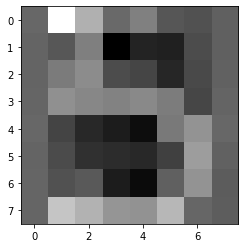

```python
plt.imshow(np.reshape(x_train[1], (8,8)), cmap=plt.cm.gray)
y_train[1]
```

# Performing LinearDiscriminantAnalysis on Stadardized Data

# Q4. In the code below, where we standardize the data, we have used the fit_transform() for the training sample, and transform() for the testing sample, why?

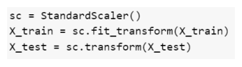

1. We use the same mean and variance calculated on the training data to fit the test data
2. The methods distinguish between the variance of each class
3. The methods distinguish between mean and standard deviation of each class.
4. None of the above

#### Answer: 1. We use the same mean and variance calculated on the training data to fit the test data

# Q5. Find the mistake in the code below?

#### lda = LinearDiscriminantAnalysis(n_components=9)

#### X_train = lda.fit_transform(X_train)

#### X_test = lda.transform(X_test)

1. Fit_transform() must include the y_train.
2. transform() must include the y_train.
3. None of the above
4. Both 1 and 2

#### Answer: 1. Fit_transform() must include the y_train.

# Q7. What is the mistake in the code below?

#### lda = LinearDiscriminantAnalysis(n_components=9)

#### X_train = lda.fit_transform(X_train, X_test)

#### X_test = lda.transform(X_test)

1. X_test instead of y_train in fit_transform()
2. X_test instead of y_train in transform()
3. n_components = 9 is incorrect
4. X_test instead of y_test in transform()

#### Answer: 1. X_test instead of y_train in fit_transform()

#### -- it must be "y_train instead of X_test in fit_transform()"

```python
lda = LDA(n_components=9)
lda_x_train = lda.fit_transform(x_train, y_train)
lda_x_test = lda.transform(x_test)
lda_x_train.shape
```

```
(1437, 9)
```

```python
y_train.shape
```

```
(1437,)
```

# Q8. How do you decide the n_components in the LinearDiscriminantAnalaysis()?

1. Correlation coefficient
2. variation inflation factor
3. explained_variance_ratio
4. None of the above

#### Answer: 3. explained_variance_ratio

# Q9. If we keep the n_components as 15 in the LDA, what will be the shape of the data?

1. (1797,15)
2. (15,15)
3. (15,)
4. (1437, 15)

#### Answer: 4. (1437, 15)

```
5
```

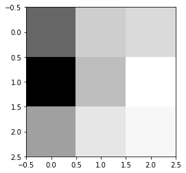

```python
plt.imshow(np.reshape(lda_x_train[1], (3,3)), cmap=plt.cm.gray)
y_train[1]
```

```python
# classify using random forest classifier
classifier = RandomForestClassifier(n_estimators=100, random_state=42)
classifier.fit(lda_x_train, y_train)
y_pred = classifier.predict(lda_x_test)
```

```python
accuracy_score(y_test,y_pred)
```

```
0.9527777777777777
```

# Q10. After performing LDA on the standardized data, with n_components= 9, Create a random forest classifier to fit the new data with n_estimators= 100, and random_state same as used in train_test_split. After the above operation, what will be the accuracy score of the model?

1. 0.75
2. 0.85
3. 0.95
4. 0.98

#### Answer: 3. 0.95

# Q11. Identify the mistake in the code below.

#### from sklearn.ensemble import RandomForestClassifier

#### rf = RandomForestClassifier(n_estimators=100, random_state=42)

#### rf.fit(X_train, X_test)

1. X_test instead of y_test
2. X_test instead of y_train
3. X_test instead of n_components = 9
4. Missing parameter - random_state=42

#### Answer: 2. X_test instead of y_train

#### -- it must be "y_train instead of X_test"

```python
conf_m = confusion_matrix(y_test,y_pred)
conf_m
```

```
array([[31,  0,  0,  1,  1,  0,  0,  0,  0,  0],
       [ 0, 26,  2,  0,  0,  0,  0,  0,  0,  0],
       [ 0,  0, 32,  1,  0,  0,  0,  0,  0,  0],
       [ 0,  0,  0, 33,  0,  1,  0,  0,  0,  0],
       [ 0,  0,  0,  0, 45,  0,  0,  1,  0,  0],
       [ 0,  0,  1,  0,  0, 45,  0,  0,  0,  1],
       [ 0,  0,  0,  0,  1,  0, 34,  0,  0,  0],
       [ 0,  0,  0,  0,  0,  0,  0, 33,  0,  1],
       [ 0,  2,  0,  0,  0,  0,  0,  0, 27,  1],
       [ 0,  0,  0,  1,  1,  0,  0,  0,  1, 37]])
```

```python
classification_report(y_test,y_pred)
```

[output not shown]

# Q12. What percentage of positive cases was the model able to catch for class 6?

1. 100
2. 97
3. 35
4. 99

# Q13. What percentage of the predictions were true for class 5?

1. 96
2. 47
3. 98
4. 0.98

#### Answer: 4. 0.98 (precision) --> 5. 0.98 0.96 0.97 47\n

# 14. What percentage of positive predictions were correct for class 3?

1. 34
2. 92
3. 97
4. 94

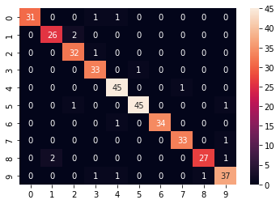

```python
import seaborn as sns
sns.heatmap(conf_m,annot=True)
```